# Nonparametric two-sample testing

Kemeng Zhang

2018-04-23

## Introduction

The nonparametric two-sample hypothesis testing problem involves: given X_1, X_2, …, X_n i.i.d. F and Y_1, Y_2, …, Y_m i.i.d. G, test the null hypothesis of F = G against the alternative hypothesis of F is not equal to G. The test statistic is based on embedding F and G into a reproducing kernel Hilbert space and then compute a distance between the resulting embeddings. For this primitive, the Hilbert space is associated with the Gaussian kernel.

## Testing/Simulation

### Stochastic Blockmodel Example

We illustrate the hypothesis tests through simulated examples. Let F_epsilon for a given epsilon > 0 be mixture of point masses corresponding to a two-block stochastic block model with block membership probabilities (0.4,0.6) and block probabilities 0.5+epsilon if in the same block, 0.2 otherwise.

Suppose we are given two graphs G ~ F_0 (known) and G_epsilon ~ F_epsilon (unknown). We then test, for a given epsilon > 0, the hypothesis whether F_0 and F_epsilon are the same distribution. We will use bootstrapping to conduct hypothesis testing. First, we need to construct a sampling distribution of our test statistic. Under null, we sample two graphs on 100 vertices from RDPG(F_0), then compute our test statistic using nonpar() 200 times. Then we can construct a rejection region and test whether the test statistic of G and G_epsilon lies inside that region (therefore we reject the null; otherwise, we fail to reject the null).

```r
# Generate Adjacency Matrix
sbm <- function(epsilon) {
  n <- 100
  blocks <- c(rep(0, n*0.4), rep(1, n*0.6))
  A <- matrix(rep(0, n*n), nrow = n)
  for (i in 2:n) {
    for (j in 1:(i-1)) {
      if (blocks[i] == blocks[j]) {
        A[i, j] <- rbinom(1, 1, 0.5 + epsilon)
      } else {
        A[i, j] <- rbinom(1, 1, 0.2)
      }
      A[j, i] <- A[i, j]
    }
  }
  g <- igraph::graph_from_adjacency_matrix(A)
  g
}
```

Now, we are given two graphs to perform hypothesis testing: G ~ F_0, G_epsilon ~ F_epsilon;

where we set epsilon to be 0.01.

```r
g = sbm(0)
g_epsilon = sbm(0.01)
```

Now, we can embed two graphs to R^2 and compare their latent positions:

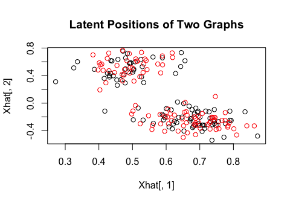

```r
Xhat = ase(g, 2)
Xhat_epsilon = ase(g_epsilon, 2)
if (sum(sign(Xhat[,2]) == -sign(Xhat_epsilon[,2])) / length(Xhat[,2]) > 0.9) {
    Xhat_epsilon[,2] = -Xhat_epsilon[,2]
}
plot(Xhat[,1],Xhat[,2],main = "Latent Positions of Two Graphs")
points(Xhat_epsilon[,1],Xhat_epsilon[,2],col = "red")
```

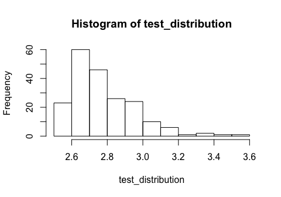

```r
test_stat <- function(g,g1,d) {
  Xhat = ase(g, d)
  Xhat_epsilon = ase(g1, d)
  # Issue: latent positions are the same up to sign.
  if (sum(sign(Xhat[,2]) == -sign(Xhat_epsilon[,2])) / length(Xhat[,2]) > 0.9) {
    Xhat_epsilon[,2] = -Xhat_epsilon[,2]
  }
  test_stats = graphstats::nonpar(Xhat,Xhat_epsilon,sigma = 0.5)
  test_stats
}
test_distribution = c()
for (i in 1:200) {
  g = sbm(0)
  g1 = sbm(0)
  test_distribution[i] = test_stat(g,g1,2)

}
hist(test_distribution)
```

Here we construct rejection region:

```r
o = order(test_distribution,decreasing = TRUE)
u = test_distribution[o][5]
test_stat_ep = test_stat(g,g_epsilon,2)
if (test_stat_ep > u) {
  print("Reject null")
} else {
  print("Fail to reject null")
}
```

```
## [1] "Fail to reject null"
```

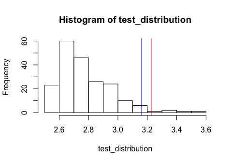

```r
hist(test_distribution)
abline(v=test_stat_ep,col="blue")
abline(v=u,col = 'red')
```